# Neural Networks

João Neto

May 2013

A neural network (NN) model is very similar to a non-linear regression model, with the exception that the former can handle an incredibly large amount of model parameters. For this reason, neural network models are said to have the ability to approximate any continuous function.

Neural network is very good at learning non-linear function and also multiple outputs can be learnt at the same time. However, the training time is relatively long and it is also susceptible to local minimum traps. This can be mitigated by doing multiple rounds and pick the best learned model.

R has several packages for dealing with NNs, like `neuralnet`, `nnet` or `RSNNS`.

## Using package neuralnet

From http://gekkoquant.com/2012/05/26/neural-networks-with-r-simple-example/

```r
library(neuralnet)

#Going to create a neural network to perform square rooting (using backpropagation)
#Type ?neuralnet for more information on the neuralnet library

#Generate 50 random numbers uniformly distributed between 0 and 100
#And store them as a dataframe
traininginput <-  as.data.frame(runif(50, min=0, max=100))
trainingoutput <- sqrt(traininginput)

#Column bind the data into one variable
trainingdata <- cbind(traininginput,trainingoutput)
colnames(trainingdata) <- c("Input","Output")

#Train the neural network with backpropagation
#Going to have 10 hidden layers
#Threshold is a numeric value specifying the threshold for the partial
#derivatives of the error function as stopping criteria.
net.sqrt <- neuralnet(Output ~ Input, trainingdata, hidden=10, threshold=0.01)
print(net.sqrt)
```

```
## Call: neuralnet(formula = Output ~ Input, data = trainingdata, hidden = 10,     threshold = 0.01)
##
## 1 repetition was calculated.
##
##             Error Reached Threshold Steps
## 1 0.0006282191137    0.009245995019  6812
```

[figure not shown]

```r
#Plot the neural network
plot(net.sqrt)
```

```r
#Test the neural network on some training data
testdata <- as.data.frame((1:10)^2) #Generate some squared numbers
net.results <- compute(net.sqrt, testdata) #Run them through the neural network

#Lets see what properties net.sqrt has
ls(net.results)
```

```
## [1] "net.result" "neurons"
```

```r
#Lets see the results
print(net.results$net.result)
```

```
##               [,1]
##  [1,] 0.9143358513
##  [2,] 1.9942238404
##  [3,] 3.0005677587
##  [4,] 3.9981018905
##  [5,] 5.0008748616
##  [6,] 6.0022207302
##  [7,] 6.9938605784
##  [8,] 7.9987651833
##  [9,] 9.0110881921
## [10,] 9.9793247077
```

```r
#Lets display a better version of the results
cleanoutput <- cbind(testdata,sqrt(testdata),
                         as.data.frame(net.results$net.result))
colnames(cleanoutput) <- c("Input","Expected Output","Neural Net Output")
print(cleanoutput)
```

```
##    Input Expected Output Neural Net Output
## 1      1               1      0.9143358513
## 2      4               2      1.9942238404
## 3      9               3      3.0005677587
## 4     16               4      3.9981018905
## 5     25               5      5.0008748616
## 6     36               6      6.0022207302
## 7     49               7      6.9938605784
## 8     64               8      7.9987651833
## 9     81               9      9.0110881921
## 10   100              10      9.9793247077
```

Another [example](http://horicky.blogspot.pt/2012/06/predictive-analytics-neuralnet-bayesian.html)

```r
library(neuralnet)

set.seed(101)
size.sample <- 50
iristrain <- iris[sample(1:nrow(iris), size.sample),] # get a training sample from iris
nnet_iristrain <- iristrain

# Binarize the categorical output
nnet_iristrain <- cbind(nnet_iristrain, iristrain$Species == 'setosa')
nnet_iristrain <- cbind(nnet_iristrain, iristrain$Species == 'versicolor')
nnet_iristrain <- cbind(nnet_iristrain, iristrain$Species == 'virginica')

names(nnet_iristrain)[6] <- 'setosa'
names(nnet_iristrain)[7] <- 'versicolor'
names(nnet_iristrain)[8] <- 'virginica'

head(nnet_iristrain)
```

```
##     Sepal.Length Sepal.Width Petal.Length Petal.Width    Species setosa
## 56           5.7         2.8          4.5         1.3 versicolor  FALSE
## 7            4.6         3.4          1.4         0.3     setosa   TRUE
## 106          7.6         3.0          6.6         2.1  virginica  FALSE
## 97           5.7         2.9          4.2         1.3 versicolor  FALSE
## 37           5.5         3.5          1.3         0.2     setosa   TRUE
## 44           5.0         3.5          1.6         0.6     setosa   TRUE
##     versicolor virginica
## 56        TRUE     FALSE
## 7        FALSE     FALSE
## 106      FALSE      TRUE
## 97        TRUE     FALSE
## 37       FALSE     FALSE
## 44       FALSE     FALSE
```

[figure not shown]

```r
nn <- neuralnet(setosa+versicolor+virginica ~
                Sepal.Length+Sepal.Width
                            +Petal.Length
                            +Petal.Width,
                data=nnet_iristrain,
                hidden=c(3))

plot(nn)
```

```r
mypredict <- compute(nn, iris[-5])$net.result
# Put multiple binary output to categorical output
maxidx <- function(arr) {
    return(which(arr == max(arr)))
}
idx <- apply(mypredict, c(1), maxidx)
prediction <- c('setosa', 'versicolor', 'virginica')[idx]
table(prediction, iris$Species)
```

```
##
## prediction   setosa versicolor virginica
##   setosa         50          0         0
##   versicolor      0         47         3
##   virginica       0          3        47
```

## Using package nnet

From http://www.r-bloggers.com/visualizing-neural-networks-from-the-nnet-package/

Let’s use the iris dataset as an example:

```r
library(nnet)

ir      <- rbind(iris3[,,1], iris3[,,2], iris3[,,3])
targets <- class.ind( c(rep("s", 50), rep("c", 50), rep("v", 50)) )
samp    <- c(sample(1:50,25), sample(51:100,25), sample(101:150,25))
nn.iris <- nnet(ir[samp,], targets[samp,], size = 2, rang = 0.1,decay = 5e-4, maxit = 200)
```

This is a plot function for nnet neural nets called `plotnet`. Read https://beckmw.wordpress.com/2013/11/14/visualizing-neural-networks-in-r-update/ for visualizing options.

Here are some:

- mod.in model object for input created from nnet function
- nid logical value indicating if neural interpretation diagram is plotted, default T
- all.out logical value indicating if all connections from each response variable are plotted, default T
- all.in logical value indicating if all connections to each input variable are plotted, default T
- wts.only logical value indicating if connections weights are returned rather than a plot, default F
- rel.rsc numeric value indicating maximum width of connection lines, default 5
- circle.cex numeric value indicating size of nodes, passed to cex argument, default 5
- node.labs logical value indicating if text labels are plotted, default T
- line.stag numeric value that specifies distance of connection weights from nodes
- cex.val numeric value indicating size of text labels, default 1
- alpha.val numeric value (0-1) indicating transparency of connections, default 1
- circle.col text value indicating color of nodes, default ‘lightgrey’
- pos.col text value indicating color of positive connection weights, default ‘black’
- neg.col text value indicating color of negative connection weights, default ‘grey’

Now let’s plot the previous trained neural net:

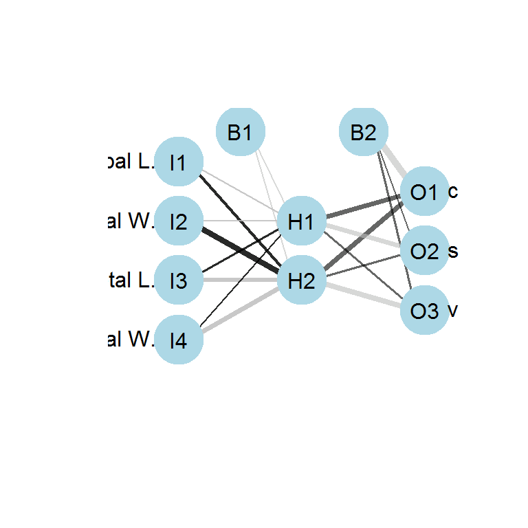

```r
library(NeuralNetTools)

plotnet(nn.iris, alpha=0.6)
```

## Using NNs via the Caret package

The caret package (short for classification and regression training) contains functions to streamline the model training process for complex regression and classification problems.

Check http://caret.r-forge.r-project.org/modelList.html for a list of available methods.

```r
library(quantmod)
library(nnet)
library(caret)
t <- seq(0,20,length=200)                       # time stamps
y <- 1 + 3*cos(4*t+2) +.2*t^2 + rnorm(200)      # the time series we want to predict
dat <- data.frame( y, x1=Lag(y,1), x2=Lag(y,2)) # create a triple with lagged values
names(dat) <- c('y','x1','x2')
head(dat)
```

```
##               y            x1            x2
## 1 -1.0628369855            NA            NA
## 2 -0.9461638315 -1.0628369855            NA
## 3 -2.4148119350 -0.9461638315 -1.0628369855
## 4  0.1578938481 -2.4148119350 -0.9461638315
## 5 -0.4744434653  0.1578938481 -2.4148119350
## 6 -0.1407492830 -0.4744434653  0.1578938481
```

```r
#Fit model
model <- train(y ~ x1+x2, dat, method='nnet', linout=TRUE, trace = FALSE)
```

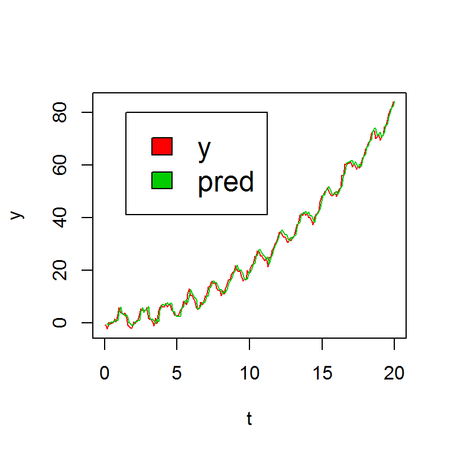

```r
ps <- predict(model, dat)

#Examine results

plot(t,y,type="l",col = 2)
lines(t[-c(1:2)],ps, col=3)
legend(1.5, 80, c("y", "pred"), cex=1.5, fill=2:3)
```

Caret is also able to make train/test sets. Using Caret for the isis dataset:

```r
inTrain <- createDataPartition(y=iris$Species, p=0.75, list=FALSE)   # We wish 75% for the trainset

train.set <- iris[inTrain,]
test.set  <- iris[-inTrain,]
nrow(train.set)/nrow(test.set) # should be around 3
```

```
## [1] 3.166666667
```

```r
model <- train(Species ~ ., train.set, method='nnet', trace = FALSE) # train
# we also add parameter 'preProc = c("center", "scale"))' at train() for centering and scaling the data
prediction <- predict(model, test.set[-5])                           # predict
table(prediction, test.set$Species)                                  # compare
```

```
##
## prediction   setosa versicolor virginica
##   setosa         12          0         0
##   versicolor      0         12         1
##   virginica       0          0        11
```

```r
# predict can also return the probability for each class:
prediction <- predict(model, test.set[-5], type="prob")
head(prediction)
```

```
##          setosa     versicolor      virginica
## 3  0.9833909273 0.012318908806 0.004290163909
## 13 0.9804309544 0.014774233586 0.004794812024
## 17 0.9876425117 0.008858596249 0.003498892061
## 30 0.9766536305 0.017949582649 0.005396786813
## 31 0.9751143511 0.019253775537 0.005631873333
## 34 0.9884559227 0.008206873188 0.003337204088
```